# Week12_IP

## Bivariate Analysis

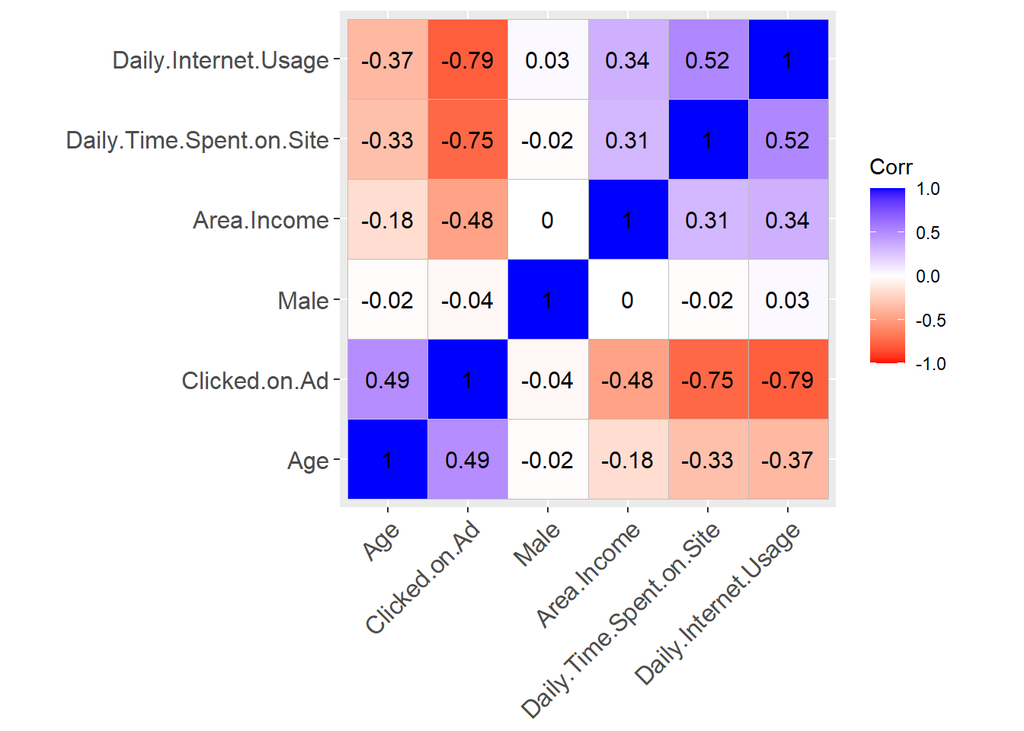

```r
# Checking the correlation coefficients for numeric variables

install.packages("ggcorrplot")
library(ggcorrplot)
corr = round(cor(select_if(crypto_numeric, is.numeric)), 2)
ggcorrplot(corr, hc.order = T, ggtheme = ggplot2::theme_gray,
   colors = c("red", "white", "blue"), lab = T)
```

OBSERVATION: There is a a negative correlation between daily internet usage, daily time spent on site and Area Income vs clicked on ad.

##Covariance between Daily Internet Usage and Area Income

```r
Daily.Internet.Usage <- crypto_ads$Daily.Internet.Usage
Area.Income <- crypto_ads$Area.Income
cov(Daily.Internet.Usage, Area.Income)
```

```
## [1] 198762.5
```

##Covariance between Daily Internet Usage and Age on the Site

```r
Daily.Internet.Usage <- crypto_ads$Daily.Internet.Usage
Ages <- crypto_ads$Age
cov(Daily.Internet.Usage, Ages)
```

```
## [1] -141.6348
```

##Covariance between age and area income on site

```r
Area_Income <- crypto_ads$Area.Income
age <- crypto_ads$Age
cov(Area.Income, age)
```

```
## [1] -21520.93
```

##Covariance between Daily Internet Usage and Area income

```r
Daily_Internet_Usage <- crypto_ads$Daily.Internet.Usage
Area.Income <- crypto_ads$Area.Income
cov(Daily.Internet.Usage, Area.Income)
```

```
## [1] 198762.5
```

# Daily Time spent on site and Age.

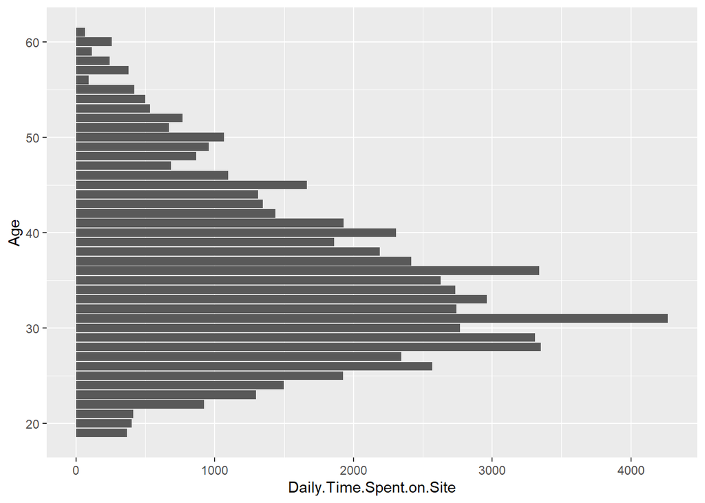

```r
library(ggplot2)
# Barplot
p<-ggplot(data=crypto_ads, aes(x=Age, y=Daily.Time.Spent.on.Site)) +
  geom_bar(stat="identity")
p + coord_flip()
```

```r
colnames(crypto_ads)
```

```
##  [1] "Daily.Time.Spent.on.Site" "Age"
##  [3] "Area.Income"              "Daily.Internet.Usage"
##  [5] "Ad.Topic.Line"            "City"
##  [7] "Male"                     "Country"
##  [9] "Timestamp"                "Clicked.on.Ad"
```

###Daily time spent on site

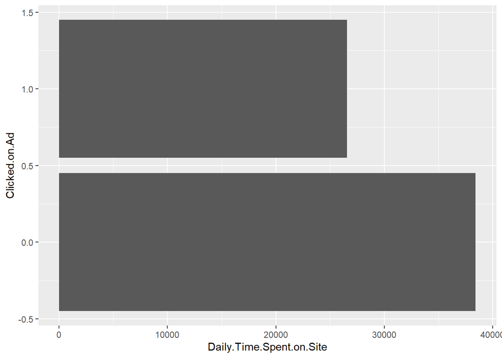

```r
library(ggplot2)
# Barplot
p<-ggplot(data=crypto_ads, aes(x=Clicked.on.Ad, y=Daily.Time.Spent.on.Site)) +
  geom_bar(stat="identity")
p + coord_flip()
```

# Scatter plot to compare age vs daily time spent

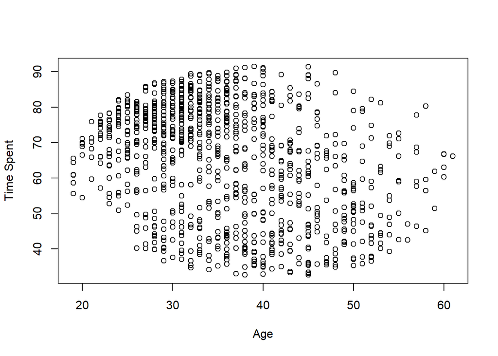

```r
plot(crypto_ads$Age, crypto_ads$Daily.Time.Spent.on.Site, xlab="Age", ylab="Time Spent")
```

# Scatter plot to compare Clicked on Ad vs Time Spent

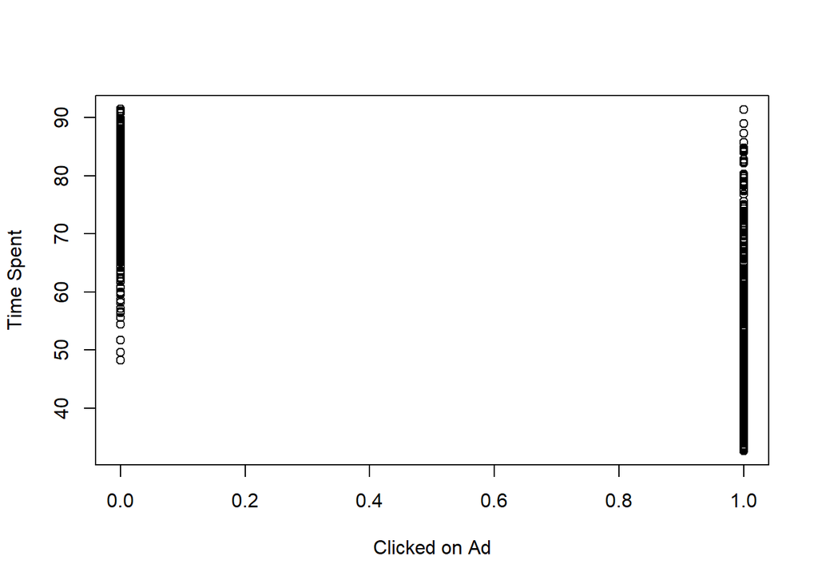

```r
plot(crypto_ads$Clicked.on.Ad, crypto_ads$Daily.Time.Spent.on.Site, xlab="Clicked on Ad", ylab="Time Spent")
```

# Implement the Solution by Using Decision Trees

# Importing relevant libraries

```r
install.packages("rpart")
```

```r
install.packages("rpart.plot")
install.packages("mlbench")
install.packages("caret")
library(rpart)
library(rpart.plot)
library(mlbench)
library(caret)
```